# 02_Anthropetry

## 1. Load Libraries and Data

```r
# Data Manipulation
library(dplyr)
library(tidyr)
library(readr)
library(here)
library(purrr)
# Visualization
library(ggplot2)
library(skimr)  # For comprehensive summary
library(janitor)  # for cleaning column names
library(visdat)   # visualize missingness
library(mice)     # for advanced imputation
```

```r
# Load data with correct path from project root
anth_df <- read.csv(here("data", "raw", "anthropometry_national_zaf.csv"))

# Skip first metadata row
anth_df <- anth_df[-1, ]

cat("Initial dataset loaded successfully.\n")
```

```
## Initial dataset loaded successfully.
```

```r
cat("Dimensions:", dim(anth_df), "\n")
```

```
## Dimensions: 37 29
```

# 2. Initial Data Assessment ———————————————–

```r
# Clean column names
anth_df <- janitor::clean_names(anth_df)
colnames(anth_df)
```

```
##  [1] "iso3"                    "data_id"
##  [3] "indicator"               "value"
##  [5] "precision"               "dhs_country_code"
##  [7] "country_name"            "survey_year"
##  [9] "survey_id"               "indicator_id"
## [11] "indicator_order"         "indicator_type"
## [13] "characteristic_id"       "characteristic_order"
## [15] "characteristic_category" "characteristic_label"
## [17] "by_variable_id"          "by_variable_label"
## [19] "is_total"                "is_preferred"
## [21] "sdrid"                   "region_id"
## [23] "survey_year_label"       "survey_type"
## [25] "denominator_weighted"    "denominator_unweighted"
## [27] "ci_low"                  "ci_high"
## [29] "level_rank"
```

```r
# Peek at structure and summary
glimpse(anth_df)
```

```
## Rows: 37
## Columns: 29
## $ iso3                    <chr> "ZAF", "ZAF", "ZAF", "ZAF", "ZAF", "ZAF", "ZAF…
## $ data_id                 <chr> "198690", "198687", "198688", "597227", "59722…
## $ indicator               <chr> "Children severely stunted", "Children stunted…
## $ value                   <chr> "9.8", "27.4", "-1.1", "0.6", "2.5", "13.3", "…
## $ precision               <chr> "1", "1", "1", "1", "1", "1", "1", "1", "1", "…
## $ dhs_country_code        <chr> "ZA", "ZA", "ZA", "ZA", "ZA", "ZA", "ZA", "ZA"…
## $ country_name            <chr> "South Africa", "South Africa", "South Africa"…
## $ survey_year             <chr> "2016", "2016", "2016", "2016", "2016", "2016"…
## $ survey_id               <chr> "ZA2016DHS", "ZA2016DHS", "ZA2016DHS", "ZA2016…
## $ indicator_id            <chr> "CN_NUTS_C_HA3", "CN_NUTS_C_HA2", "CN_NUTS_C_H…
## $ indicator_order         <int> 104236010, 104236020, 104236030, 104236040, 10…
## $ indicator_type          <chr> "I", "I", "I", "I", "I", "I", "I", "I", "I", "…
## $ characteristic_id       <int> 1000, 1000, 1000, 1000, 1000, 1000, 1000, 1000…
```

[output cut: 16 more lines]

```r
skim(anth_df)
```

Data summary

| Name | anth_df |
| --- | --- |
| Number of rows | 37 |
| Number of columns | 29 |
| _______________________ |  |
| Column type frequency: |  |
| character | 17 |
| logical | 4 |
| numeric | 8 |
| ________________________ |  |
| Group variables | None |

**Variable type: character**

| skim_variable | n_missing | complete_rate | min | max | empty | n_unique | whitespace |
| --- | --- | --- | --- | --- | --- | --- | --- |
| iso3 | 0 | 1 | 3 | 3 | 0 | 1 | 0 |
| data_id | 0 | 1 | 5 | 6 | 0 | 37 | 0 |
| indicator | 0 | 1 | 13 | 59 | 0 | 33 | 0 |
| value | 0 | 1 | 2 | 4 | 0 | 36 | 0 |
| precision | 0 | 1 | 1 | 1 | 0 | 2 | 0 |
| dhs_country_code | 0 | 1 | 2 | 2 | 0 | 1 | 0 |
| country_name | 0 | 1 | 12 | 12 | 0 | 1 | 0 |
| survey_year | 0 | 1 | 4 | 4 | 0 | 1 | 0 |
| survey_id | 0 | 1 | 9 | 9 | 0 | 1 | 0 |
| indicator_id | 0 | 1 | 13 | 13 | 0 | 37 | 0 |
| indicator_type | 0 | 1 | 1 | 1 | 0 | 3 | 0 |
| characteristic_category | 0 | 1 | 5 | 11 | 0 | 2 | 0 |
| characteristic_label | 0 | 1 | 5 | 11 | 0 | 2 | 0 |
| by_variable_id | 0 | 1 | 1 | 1 | 0 | 1 | 0 |
| by_variable_label | 0 | 1 | 0 | 0 | 37 | 1 | 0 |
| sdrid | 0 | 1 | 10 | 10 | 0 | 37 | 0 |
| survey_type | 0 | 1 | 3 | 3 | 0 | 1 | 0 |

**Variable type: logical**

| skim_variable | n_missing | complete_rate | mean | count |
| --- | --- | --- | --- | --- |
| region_id | 37 | 0 | NaN | : |
| ci_low | 37 | 0 | NaN | : |
| ci_high | 37 | 0 | NaN | : |
| level_rank | 37 | 0 | NaN | : |

**Variable type: numeric**

| skim_variable | n_missing | complete_rate | mean | sd | p0 | p25 | p50 | p75 | p100 | hist |
| --- | --- | --- | --- | --- | --- | --- | --- | --- | --- | --- |
| indicator_order | 0 | 1.00 | 111493274.86 | 4785521.41 | 104236010 | 104236100 | 114563080 | 114564170 | 114564260 | ▃▁▁▁▇ |
| characteristic_id | 0 | 1.00 | 4162.16 | 4355.80 | 1000 | 1000 | 1000 | 10000 | 10000 | ▇▁▁▁▅ |
| characteristic_order | 0 | 1.00 | 3513.51 | 4839.78 | 0 | 0 | 0 | 10000 | 10000 | ▇▁▁▁▅ |
| is_total | 0 | 1.00 | 1.00 | 0.00 | 1 | 1 | 1 | 1 | 1 | ▁▁▇▁▁ |
| is_preferred | 0 | 1.00 | 1.00 | 0.00 | 1 | 1 | 1 | 1 | 1 | ▁▁▇▁▁ |
| survey_year_label | 0 | 1.00 | 2016.00 | 0.00 | 2016 | 2016 | 2016 | 2016 | 2016 | ▁▁▇▁▁ |
| denominator_weighted | 4 | 0.89 | 2336.76 | 747.16 | 1384 | 1416 | 2336 | 3081 | 3272 | ▇▁▆▁▇ |
| denominator_unweighted | 4 | 0.89 | 2432.94 | 765.44 | 1449 | 1479 | 2457 | 3210 | 3405 | ▇▁▆▁▇ |

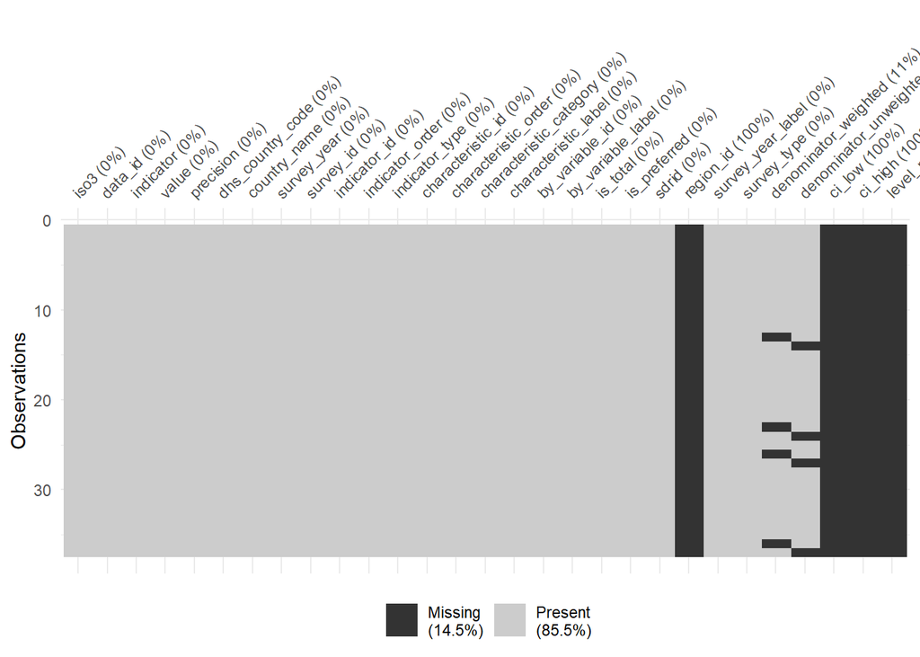

```r
# Check missingness visually
vis_miss(anth_df)
```

## 3. Data Cleaning Process

### 3.1 Handle Duplicates Systematically

- Duplicates can distort analysis. We remove exact duplicates to maintain dataset integrity.

```r
# Exact duplicates
cat("Exact duplicates:", sum(duplicated(anth_df)), "\n")
```

```
## Exact duplicates: 0
```

```r
# Keep first occurrence
anth_df <- anth_df %>% distinct()

cat("Dimensions after deduplication:", dim(anth_df), "\n")
```

```
## Dimensions after deduplication: 37 29
```

### 3.2 Convert Data Types

- Ensures numeric, integer, and logical columns are correctly typed for analysis.This prevents calculation errors and improves data quality.

```r
# Define the columns safely
numeric_cols <- intersect(c("value", "precision", "denominator_weighted", "denominator_unweighted"), colnames(anth_df))
integer_cols <- intersect(c("survey_year", "indicator_order", "characteristic_id",
                            "characteristic_order", "survey_year_label", "by_variable_id", "region_id"), colnames(anth_df))
logical_cols <- intersect(c("is_total", "is_preferred"), colnames(anth_df))

# Apply conversions only if the columns exist
anth_df <- anth_df %>%
  mutate(
    across(all_of(numeric_cols), as.numeric),
    across(all_of(integer_cols), as.integer),
    across(all_of(logical_cols), ~as.logical(as.integer(.)))
  )

cat("Data types converted successfully.\n")
```

```
## Data types converted successfully.
```

### 3.3 Handle Missing Values

- Columns with excessive missingness are dropped to maintain analysis integrity.
- Remaining missing values are imputed (numeric → median, categorical → mode) to allow modeling and prevent bias.

```r
# Summarize missingness
missing_summary <- data.frame(
  Column = names(anth_df),
  Missing_Count = colSums(is.na(anth_df)),
  Missing_Percent = round(colSums(is.na(anth_df))/nrow(anth_df)*100, 2)
) %>% arrange(desc(Missing_Percent))

print(missing_summary)
```

```
##                                          Column Missing_Count Missing_Percent
## region_id                             region_id            37          100.00
## ci_low                                   ci_low            37          100.00
## ci_high                                 ci_high            37          100.00
## level_rank                           level_rank            37          100.00
## denominator_weighted       denominator_weighted             4           10.81
## denominator_unweighted   denominator_unweighted             4           10.81
## iso3                                       iso3             0            0.00
## data_id                                 data_id             0            0.00
## indicator                             indicator             0            0.00
## value                                     value             0            0.00
## precision                             precision             0            0.00
## dhs_country_code               dhs_country_code             0            0.00
## country_name                       country_name             0            0.00
## survey_year                         survey_year             0            0.00
## survey_id                             survey_id             0            0.00
## indicator_id                       indicator_id             0            0.00
## indicator_order                 indicator_order             0            0.00
## indicator_type                   indicator_type             0            0.00
## characteristic_id             characteristic_id             0            0.00
## characteristic_order       characteristic_order             0            0.00
## characteristic_category characteristic_category             0            0.00
## characteristic_label       characteristic_label             0            0.00
## by_variable_id                   by_variable_id             0            0.00
## by_variable_label             by_variable_label             0            0.00
## is_total                               is_total             0            0.00
## is_preferred                       is_preferred             0            0.00
## sdrid                                     sdrid             0            0.00
## survey_year_label             survey_year_label             0            0.00
## survey_type                         survey_type             0            0.00
```

```r
# Drop columns with >40% missing values
cols_to_drop <- missing_summary %>% filter(Missing_Percent > 40) %>% pull(Column)
anth_df <- anth_df %>% select(-all_of(cols_to_drop))

# Impute remaining missing values: median for numeric, mode for categorical
impute_mode <- function(x) {
  ux <- na.omit(x)
  if(length(ux)==0) return(x)
  rep(names(sort(table(ux), decreasing=TRUE))[1], length(x))
}

anth_df <- anth_df %>%
  mutate(across(where(is.numeric), ~ifelse(is.na(.), median(., na.rm=TRUE), .))) %>%
  mutate(across(where(is.character), ~ifelse(is.na(.), impute_mode(.), .)))

cat("Remaining NAs after imputation:", sum(is.na(anth_df)), "\n")
```

```
## Remaining NAs after imputation: 0
```

### 3.4 Remove redundant columns

- Metadata columns such as survey type or country identifiers are removed as they do not contribute to analysis.

```r
# -----------------------------
# Remove redundant columns
# -----------------------------
# Define columns that are metadata or unnecessary for analysis
redundant_cols <- c("survey_type", "survey_id", "country_name", "iso3")  # adjust names to match anth_df

# Remove them safely
anth_df <- anth_df %>%
  select(-any_of(redundant_cols))

cat("Redundant columns removed. New dimensions:", dim(anth_df), "\n")
```

```
## Redundant columns removed. New dimensions: 37 21
```

### 3.5 Remove columns with all missing values

- Detect numeric/logical columns that have all missing values.
- Remove them without touching the rest of the data.
- Report what was removed and the new dataset dimensions.

```r
# Remove columns that are completely NA or have no valid numeric/logical data
cols_to_remove <- anth_df %>%
  select(where(~all(is.na(.) | is.nan(.)))) %>%
  colnames()

anth_df <- anth_df %>% select(-all_of(cols_to_remove))

cat("Removed empty/unusable columns. New dimensions:", dim(anth_df), "\n")
```

```
## Removed empty/unusable columns. New dimensions: 37 21
```

# Handle Outliers

```r
# Detect numeric columns
num_cols <- anth_df %>% select(where(is.numeric))

# Compute IQR bounds
outlier_bounds <- function(x) {
  qnt <- quantile(x, probs=c(0.25, 0.75), na.rm=TRUE)
  iqr <- diff(qnt)
  c(lower=qnt[1]-1.5*iqr, upper=qnt[2]+1.5*iqr)
}

bounds <- map(num_cols, outlier_bounds)

# Winsorize numeric variables
anth_df <- anth_df %>%
  mutate(across(where(is.numeric),
                ~pmin(pmax(., bounds[[cur_column()]]["lower"]),
                      bounds[[cur_column()]]["upper"])))
```

### 3.5 Deal with Noise / Special Values

- Special values like negative heights/weights are logically impossible.Any negative value is replaced by the median of that column.

```r
anth_df <- anth_df %>%
  mutate(across(matches("height|weight"),
                ~ifelse(. < 0, median(., na.rm = TRUE), .)))
```

## 4. Final Data Validation

```r
cat("=== FINAL CLEANED DATA ===\n")
```

```
## === FINAL CLEANED DATA ===
```

```r
cat("Dimensions:", dim(anth_df), "\n")
```

```
## Dimensions: 37 21
```

```r
skim(anth_df)
```

Data summary

| Name | anth_df |
| --- | --- |
| Number of rows | 37 |
| Number of columns | 21 |
| _______________________ |  |
| Column type frequency: |  |
| character | 9 |
| logical | 4 |
| numeric | 8 |
| ________________________ |  |
| Group variables | None |

**Variable type: character**

| skim_variable | n_missing | complete_rate | min | max | empty | n_unique | whitespace |
| --- | --- | --- | --- | --- | --- | --- | --- |
| data_id | 0 | 1 | 5 | 6 | 0 | 37 | 0 |
| indicator | 0 | 1 | 13 | 59 | 0 | 33 | 0 |
| dhs_country_code | 0 | 1 | 2 | 2 | 0 | 1 | 0 |
| indicator_id | 0 | 1 | 13 | 13 | 0 | 37 | 0 |
| indicator_type | 0 | 1 | 1 | 1 | 0 | 3 | 0 |
| characteristic_category | 0 | 1 | 5 | 11 | 0 | 2 | 0 |
| characteristic_label | 0 | 1 | 5 | 11 | 0 | 2 | 0 |
| by_variable_label | 0 | 1 | 0 | 0 | 37 | 1 | 0 |
| sdrid | 0 | 1 | 10 | 10 | 0 | 37 | 0 |

**Variable type: logical**

| skim_variable | n_missing | complete_rate | mean | count |
| --- | --- | --- | --- | --- |
| is_total | 0 | 1 | 1 | TRU: 37 |
| is_preferred | 0 | 1 | 1 | TRU: 37 |
| denominator_weighted | 37 | 0 | NaN | : |
| denominator_unweighted | 37 | 0 | NaN | : |

**Variable type: numeric**

| skim_variable | n_missing | complete_rate | mean | sd | p0 | p25 | p50 | p75 | p100 | hist |
| --- | --- | --- | --- | --- | --- | --- | --- | --- | --- | --- |
| value | 37 | 0 | NaN | NA | NA | NA | NA | NA | NA |  |
| precision | 37 | 0 | NaN | NA | NA | NA | NA | NA | NA |  |
| survey_year | 37 | 0 | NaN | NA | NA | NA | NA | NA | NA |  |
| indicator_order | 37 | 0 | NaN | NA | NA | NA | NA | NA | NA |  |
| characteristic_id | 37 | 0 | NaN | NA | NA | NA | NA | NA | NA |  |
| characteristic_order | 37 | 0 | NaN | NA | NA | NA | NA | NA | NA |  |
| by_variable_id | 37 | 0 | NaN | NA | NA | NA | NA | NA | NA |  |
| survey_year_label | 37 | 0 | NaN | NA | NA | NA | NA | NA | NA |  |

## 5. Save Cleaned Data

```r
write_csv(anth_df, here("data", "processed", "anthropometry_cleaned.csv"))
cat("Cleaned dataset saved to data/processed/anthropometry_cleaned.csv\n")
```

```
## Cleaned dataset saved to data/processed/anthropometry_cleaned.csv
```